# Ch. 2: Estimation

```r
library(faraway)
library(dplyr)
library(ggplot2)
```

First, we introduce the general framework of statistical modeling and then we focus our attention on linear models as a special case.

In an observational study, a statistical model for the data can be represented in the following form. We have a finite sample of observational units (e.g. individuals) $i = 1,\ldots, n$. For each unit in the sample, we have some covariate information $x_i \in \mathcal{X}$ and a response measurement $Y_i \in \mathcal{Y}$. The response variable is capitalized because it is usually treated as a realization of a random variable. In linear regression, we have $\mathcal{Y} = \mathbb{R}$ and for now we take $\mathcal{X} = \mathbb{R}^d$ (this isn’t strictly necessary, we can have discrete or categorical covariates). The general regression model (i.e. joint distribution on the $Y_i$) takes the form:
$$Y_i = f(x_i) + \epsilon_i \qquad i = 1,\ldots,n$$
where $\epsilon_i$ are iid copies of mean-zero additive noise. This treats the $Y_i$ as independent but with different means; if we take $\epsilon_i \overset{\text{iid}}{\sim} \mathcal{N}(0, \sigma^2)$, then we can write the model as
$$\begin{bmatrix}
Y_1 \\
Y_2 \\
\vdots \\
Y_n
\end{bmatrix}
\sim
\mathcal{N}\left(
\begin{bmatrix}
f(x_1) \\
f(x_2) \\
\vdots \\
f(x_n)
\end{bmatrix}\;
, \;
\begin{bmatrix}
\sigma^2 & \\
& \sigma^2 \\
& & \ddots \\
& & & \sigma^2
\end{bmatrix}
\right)\;.$$
The linear model makes the further assumption that $f(x_i) = \beta^\mathsf{T}x_i$ so we can plug this into the model above and obtain
$$\begin{bmatrix}
Y_1 \\
Y_2 \\
\vdots \\
Y_n
\end{bmatrix}
\sim
\mathcal{N}\left(
\begin{bmatrix}
-\;x_1^\mathsf{T}\;- \\
-\;x_2^\mathsf{T}\;- \\
\vdots \\
-\;x_n^\mathsf{T}\;-
\end{bmatrix}\cdot\beta\;
, \;
\begin{bmatrix}
\sigma^2 & \\
& \sigma^2 \\
& & \ddots \\
& & & \sigma^2
\end{bmatrix}
\right)
\doteq
\mathbb{P}_{\beta,\sigma}$$
or more succinctly, the compact formula
$$Y = X\beta + \epsilon \quad, \quad\epsilon \sim \mathcal{N}(0, \sigma^2I_n)\;.$$

Note that the mean structure is not as restrictive as it may seem, since we can transform the coordinates of the $x_i$ in complicated ways before plugging them into the model; the linearity only really refers to the act of taking a linear combination $\beta^\mathsf{T}x_i$. In the one-dimensional case $d=1$ with a single real-valued covariate, this graphic provides a visualization of the linear model:

https://slideplayer.com/slide/6308044/21/images/7/Conditions+for+inference.jpg

So we have a random vector $Y \in \mathbb{R}^n$ of response measurements and we have a class of candidate distributions $\mathcal{P} = \left\{ \mathbb{P}_{\beta, \sigma}: \beta\in \mathbb{R}^d\;, \; \sigma>0\right\}$. Is this a reasonable model class? How do we select a distribution (i.e. pin down settings for $\beta, \sigma$) based on our observed data? We address the second question first. One common method for fitting the parameters is maximum likelihood: under which setting of $\beta$ (and $\sigma$) are the observed data most likely to have been generated? To this end, we write down the (log-)likelihood
$$\ell(Y\; ;\; \beta, \sigma) \doteq \log \left( \prod_{i=1}^n \mathcal{N}(Y_i\;;\; \beta^\mathsf{T} x_i, \sigma)\right) = -\frac{n}{2}\log(2\pi \sigma^2) - \frac{1}{2\sigma^2}\sum_{i=1}^n (Y_i - \beta^\mathsf{T}x_i)^2$$
which can serve as a reasonable “objective function”; we maximize the log-likelihood of the observed data to obtain estimates of $\beta, \sigma$. It can be seen that this objective is concave in $\beta$, and if we differentiate the objective with respect to $\beta$ and set it to zero, we obtain the “normal equations” which yield a closed form for the estimator
$$X^\mathsf{T}X \hat{\beta} = X^\mathsf{T}Y \qquad \implies \qquad \hat{\beta} = (X^\mathsf{T}X)^{-1}X^\mathsf{T}Y\;.$$
We can also differentiate the objective with respect to $\sigma^2$ and set to zero to obtain the estimator
$$\hat{\sigma}^2 = \frac{1}{n}\lVert Y - X\hat{\beta} \rVert^2\;.$$
Often times in software packages, the estimator for $\sigma^2$ is modified slightly
$$\hat{\sigma}^2 = \frac{1}{n-d}\lVert Y - X\hat{\beta} \rVert^2$$
but we won’t get into the exact reasons for that until the next chapter. This estimator is called the “residual standard error”.

We have been treating $\beta, \sigma$ as parameters, but if we truly believe in the proposed linear model, then we would make a “realizability assumption” and claim that there are “true” underlying values $\beta_*, \sigma_*$ that generated the data. The salient features of this realizability assumption are:

1. The $Y_i$ are independent gaussians with common variance $\sigma_*^2$ that doesn’t depend on the units $i = 1,\ldots,n$ (either through the covariates $x_i$ or otherwise).
2. The mean of $Y_i$ is given by the linear combination $\beta_*^\mathsf{T}x_i$ where the coefficient vector $\beta_*$ is common across $i = 1,\ldots,n$.

The realizability assumption is only needed if we want to perform “inference”, but we leave that for the next chapter. We can always just fit the linear model and obtain estimates without waxing philosophical about whether the realizability assumption holds. However, notice that the estimator $\hat{\beta}$ relies on inverting $X^\mathsf{T}X\in \mathbb{R}^{d\times d}$. This matrix will be nonsingular if $X\in \mathbb{R}^{n\times d}$ is full rank (linearly independent columns), which is usually the case if $d \le n$. If $d > n$ then we need to enforce further constraints on the optimization problem (maximum-likelihood) to uniquely identify a solution. There are a plethora of penalized regression strategies designed to address this issue which we will take up later.

### Exercise 1

The dataset teengamb concerns a study of teenage gambling in Britain. Fit a regression model with the expenditure on gambling as the response and the sex, status, income and verbal score as predictors. Present the output.

**Answer:** We reproduce the first few lines of code that we used in Ch. 1:

```r
data('teengamb')
dim(teengamb)
```

```
## [1] 47  5
```

We have 47 cases, with 5 variables measured in each case.

```r
teengamb$sex = as.factor(teengamb$sex)
summary(teengamb)
```

```
##  sex        status          income           verbal          gamble
##  0:28   Min.   :18.00   Min.   : 0.600   Min.   : 1.00   Min.   :  0.0
##  1:19   1st Qu.:28.00   1st Qu.: 2.000   1st Qu.: 6.00   1st Qu.:  1.1
##         Median :43.00   Median : 3.250   Median : 7.00   Median :  6.0
##         Mean   :45.23   Mean   : 4.642   Mean   : 6.66   Mean   : 19.3
##         3rd Qu.:61.50   3rd Qu.: 6.210   3rd Qu.: 8.00   3rd Qu.: 19.4
##         Max.   :75.00   Max.   :15.000   Max.   :10.00   Max.   :156.0
```

From the page $\texttt{?teengamb}$, the definitions of the variables are

- sex: 0 = male, 1 = female
- status: socioeconomic status score based on parents’ occupation
- income: in pounds per week
- verbal: verbal score in words out of 12 correctly defined
- gamble: expenditure on gambling in pounds per year

Now we fit the linear model to this dataset.

```r
lmod = lm(gamble ~ sex + status + income + verbal, data=teengamb)
summary(lmod)
```

```
##
## Call:
## lm(formula = gamble ~ sex + status + income + verbal, data = teengamb)
##
## Residuals:
##     Min      1Q  Median      3Q     Max
## -51.082 -11.320  -1.451   9.452  94.252
##
## Coefficients:
##              Estimate Std. Error t value Pr(>|t|)
## (Intercept)  22.55565   17.19680   1.312   0.1968
## sex1        -22.11833    8.21111  -2.694   0.0101 *
## status        0.05223    0.28111   0.186   0.8535
## income        4.96198    1.02539   4.839 1.79e-05 ***
## verbal       -2.95949    2.17215  -1.362   0.1803
## ---
## Signif. codes:  0 '***' 0.001 '**' 0.01 '*' 0.05 '.' 0.1 ' ' 1
##
## Residual standard error: 22.69 on 42 degrees of freedom
## Multiple R-squared:  0.5267, Adjusted R-squared:  0.4816
## F-statistic: 11.69 on 4 and 42 DF,  p-value: 1.815e-06
```

**Q1.** What percentage of variation in the response is explained by these predictors?

**Answer:** The “percentage of variance explained” or “coefficient of determination” is given by the $R^2$ value, defined as
$$R^2 = 1 - \frac{\lVert Y - X\hat{\beta}\rVert^2}{\lVert Y - \bar{Y}\cdot\mathbf{1}\rVert^2}$$
which intuitively captures the decrease in the residual sum of squares as a result of adding our predictors into the model over just a simple intercept. The R output gives $R^2 = 0.5267$ here.

**Q2.** Which observation has the largest (positive) residual? Give the case number.

**Answer:**

```r
which.max(lmod$residuals)
```

```
## 24
## 24
```

**Q3.** Compute the mean and median of the residuals.

**Answer:**

```r
mean(lmod$residuals)
```

```
## [1] -3.065293e-17
```

```r
median(lmod$residuals)
```

```
## [1] -1.451392
```

**Q4.** Compute the correlation of the residuals with the fitted values.

**Answer:**

```r
cor(lmod$residuals, lmod$fitted.values)
```

```
## [1] -1.070659e-16
```

It’s a very small number, which indicates that there is not much signal left in the data to extract into the mean function.

**Q5.** Compute the correlation of the residuals with the income.

**Answer:**

```r
cor(lmod$residuals, teengamb$income)
```

```
## [1] -7.242382e-17
```

### Exercise 4

The dataset $\texttt{prostate}$ comes from a study on 97 men with prostate cancer who were due to receive a radical prostatectomy. Fit a model with $\texttt{lpsa}$ as the response and $\texttt{lcavol}$ as the predictor. Record the residual standard error and the $R^2$. Now add $\texttt{lweight, svi, lbph, age, lcp, pgg45, gleason}$ to the model one at a time. For each model record the residual standard error and the $R^2$. Plot the trends in these two statistics.

**Answer:**

```r
data("prostate")
head(prostate)
```

```
##       lcavol lweight age      lbph svi      lcp gleason pgg45     lpsa
## 1 -0.5798185  2.7695  50 -1.386294   0 -1.38629       6     0 -0.43078
## 2 -0.9942523  3.3196  58 -1.386294   0 -1.38629       6     0 -0.16252
## 3 -0.5108256  2.6912  74 -1.386294   0 -1.38629       7    20 -0.16252
## 4 -1.2039728  3.2828  58 -1.386294   0 -1.38629       6     0 -0.16252
## 5  0.7514161  3.4324  62 -1.386294   0 -1.38629       6     0  0.37156
## 6 -1.0498221  3.2288  50 -1.386294   0 -1.38629       6     0  0.76547
```

First we fit a linear model with $\texttt{lpsa}$ as the response and $\texttt{lcavol}$ as the predictor.

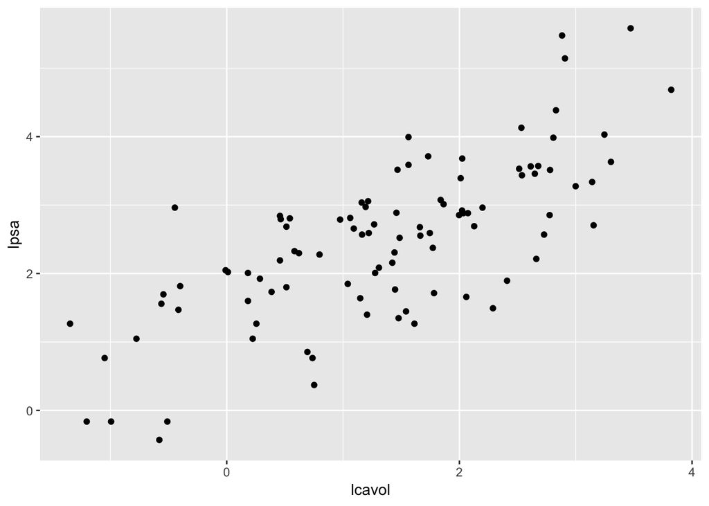

```r
ggplot(prostate) +
  geom_point(aes(x = lcavol, y = lpsa))
```

```r
lmod1 = lm(lpsa ~ lcavol, data=prostate)
summary(lmod1)
```

```
##
## Call:
## lm(formula = lpsa ~ lcavol, data = prostate)
##
## Residuals:
##      Min       1Q   Median       3Q      Max
## -1.67625 -0.41648  0.09859  0.50709  1.89673
##
## Coefficients:
##             Estimate Std. Error t value Pr(>|t|)
## (Intercept)  1.50730    0.12194   12.36   <2e-16 ***
## lcavol       0.71932    0.06819   10.55   <2e-16 ***
## ---
## Signif. codes:  0 '***' 0.001 '**' 0.01 '*' 0.05 '.' 0.1 ' ' 1
##
## Residual standard error: 0.7875 on 95 degrees of freedom
## Multiple R-squared:  0.5394, Adjusted R-squared:  0.5346
## F-statistic: 111.3 on 1 and 95 DF,  p-value: < 2.2e-16
```

Now we see how much performance is improved by adding predictors to the model. The sequence of models will take the form:

1. $\texttt{lpsa} \sim \texttt{lcavol}$
2. $\texttt{lpsa} \sim \texttt{lcavol} + \texttt{lweight}$
3. $\texttt{lpsa} \sim \texttt{lcavol} + \texttt{lweight} + \texttt{svi}$
4. $\texttt{lpsa} \sim \texttt{lcavol} + \texttt{lweight} + \texttt{svi} + \texttt{lbph}$
5. $\texttt{lpsa} \sim \texttt{lcavol} + \texttt{lweight} + \texttt{svi} + \texttt{lbph} + \texttt{age}$
6. $\texttt{lpsa} \sim \texttt{lcavol} + \texttt{lweight} + \texttt{svi} + \texttt{lbph} + \texttt{age} + \texttt{lcp}$
7. $\texttt{lpsa} \sim \texttt{lcavol} + \texttt{lweight} + \texttt{svi} + \texttt{lbph} + \texttt{age} + \texttt{lcp} + \texttt{pgg45}$
8. $\texttt{lpsa} \sim \texttt{lcavol} + \texttt{lweight} + \texttt{svi} + \texttt{lbph} + \texttt{age} + \texttt{lcp} + \texttt{pgg45} + \texttt{gleason}$

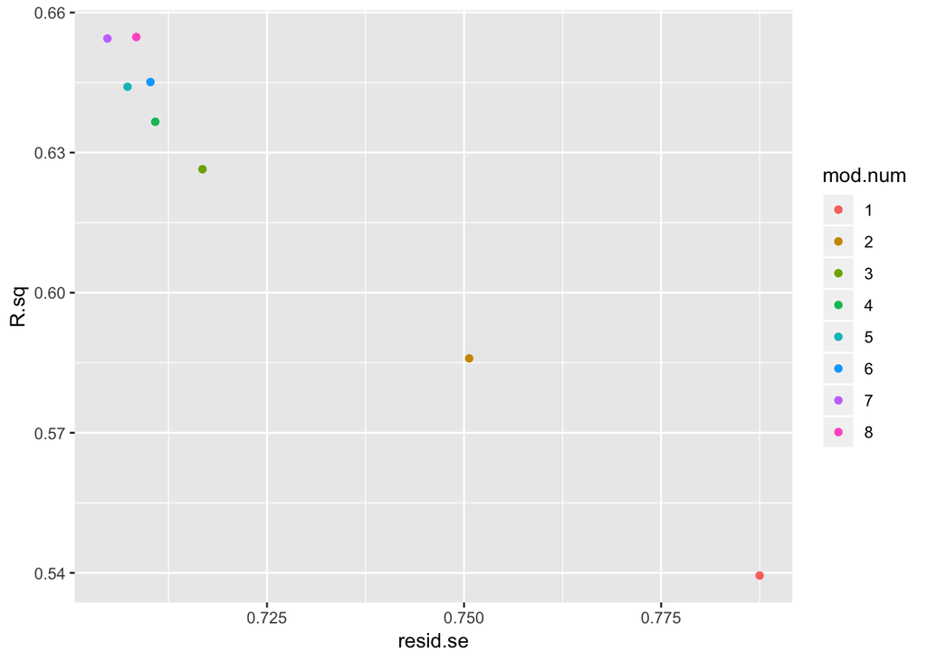

```r
performance = data.frame(mod.num = numeric(8), resid.se = numeric(8), R.sq = numeric(8))
covariates = c('lcavol', 'lweight', 'svi', 'lbph', 'age', 'lcp', 'pgg45', 'gleason')

for(i in 1:8) {
  lmod = lm(as.formula(paste('lpsa ~ ', paste(covariates[1:i], collapse = '+'))), data = prostate)
  lmod.summary = summary(lmod)
  performance[i, ] = c(i, lmod.summary$sigma, lmod.summary$r.squared)
}

performance$mod.num = as.factor(performance$mod.num)

ggplot(performance) +
  geom_point(aes(x = resid.se, y = R.sq, col = mod.num))
```

### References

1. Faraway, J. Linear Models with R.
2. McCullagh, P. Lecture notes on applied statistics. http://www.stat.uchicago.edu/~pmcc/courses/stat345/notes.pdf
3. Christensen, R. Plane Answers to Complex Questions.